# Part-1

## About the dataset

This is perhaps the best known database to be found in the pattern recognition literature. The data set contains 3 classes of 50 instances each, where each class refers to a type of iris plant. One class is linearly separable from the other 2; the latter are NOT linearly separable from each other.

Attribute Information:

1. sepal length in cm
2. sepal width in cm
3. petal length in cm
4. petal width in cm
5. class: -- Iris Setosa -- Iris Versicolour -- Iris Virginica

### Read the dataset and store it in the dataframe named Iris

```python
import pandas as pd

Iris = pd.read_csv('Iris.csv')

Iris.head()
```

|  | Sepal Length (in cm) | Sepal Width in (cm) | Petal length (in cm) | Petal width (in cm) | Class |
| --- | --- | --- | --- | --- | --- |
| 0 | 5.1 | 3.5 | 1.4 | 0.2 | Iris-setosa |
| 1 | 4.9 | 3.0 | 1.4 | 0.2 | Iris-setosa |
| 2 | 4.7 | 3.2 | 1.3 | 0.2 | Iris-setosa |
| 3 | 4.6 | 3.1 | 1.5 | 0.2 | Iris-setosa |
| 4 | 5.0 | 3.6 | 1.4 | 0.2 | Iris-setosa |

### Find out the datatypes of each and every column

```python
Iris.dtypes
```

```
Sepal Length (in cm)    float64
Sepal Width in (cm)     float64
Petal length (in cm)    float64
Petal width (in cm)     float64
Class                   object
dtype: object
```

### Print top 10 & bottom 10 samples from the dataframe

```python
Iris.head(10)
```

|  | Sepal Length (in cm) | Sepal Width in (cm) | Petal length (in cm) | Petal width (in cm) | Class |
| --- | --- | --- | --- | --- | --- |
| 0 | 5.1 | 3.5 | 1.4 | 0.2 | Iris-setosa |
| 1 | 4.9 | 3.0 | 1.4 | 0.2 | Iris-setosa |
| 2 | 4.7 | 3.2 | 1.3 | 0.2 | Iris-setosa |
| 3 | 4.6 | 3.1 | 1.5 | 0.2 | Iris-setosa |
| 4 | 5.0 | 3.6 | 1.4 | 0.2 | Iris-setosa |
| 5 | 5.4 | 3.9 | 1.7 | 0.4 | Iris-setosa |
| 6 | 4.6 | 3.4 | 1.4 | 0.3 | Iris-setosa |
| 7 | 5.0 | 3.4 | 1.5 | 0.2 | Iris-setosa |
| 8 | 4.4 | 2.9 | 1.4 | 0.2 | Iris-setosa |
| 9 | 4.9 | 3.1 | 1.5 | 0.1 | Iris-setosa |

```python
Iris.tail(10)
```

|  | Sepal Length (in cm) | Sepal Width in (cm) | Petal length (in cm) | Petal width (in cm) | Class |
| --- | --- | --- | --- | --- | --- |
| 140 | 6.7 | 3.1 | 5.6 | 2.4 | Iris-virginica |
| 141 | 6.9 | 3.1 | 5.1 | 2.3 | Iris-virginica |
| 142 | 5.8 | 2.7 | 5.1 | 1.9 | Iris-virginica |
| 143 | 6.8 | 3.2 | 5.9 | 2.3 | Iris-virginica |
| 144 | 6.7 | 3.3 | 5.7 | 2.5 | Iris-virginica |
| 145 | 6.7 | 3.0 | 5.2 | 2.3 | Iris-virginica |
| 146 | 6.3 | 2.5 | 5.0 | 1.9 | Iris-virginica |
| 147 | 6.5 | 3.0 | 5.2 | 2.0 | Iris-virginica |
| 148 | 6.2 | 3.4 | 5.4 | 2.3 | Iris-virginica |
| 149 | 5.9 | 3.0 | 5.1 | 1.8 | Iris-virginica |

### Find the shape of the dataset

```python
Iris.shape
```

```
(150, 5)
```

### Set the index of the dataframe to be the first column

```python
Iris.set_index("Sepal Length (in cm)",inplace=False)
```

| Sepal Length (in cm) | Sepal Width in (cm) | Petal length (in cm) | Petal width (in cm) | Class |
| --- | --- | --- | --- | --- |
| 5.1 | 3.5 | 1.4 | 0.2 | Iris-setosa |
| 4.9 | 3.0 | 1.4 | 0.2 | Iris-setosa |
| 4.7 | 3.2 | 1.3 | 0.2 | Iris-setosa |
| 4.6 | 3.1 | 1.5 | 0.2 | Iris-setosa |
| 5.0 | 3.6 | 1.4 | 0.2 | Iris-setosa |
| ... | ... | ... | ... | ... |
| 6.7 | 3.0 | 5.2 | 2.3 | Iris-virginica |
| 6.3 | 2.5 | 5.0 | 1.9 | Iris-virginica |
| 6.5 | 3.0 | 5.2 | 2.0 | Iris-virginica |
| 6.2 | 3.4 | 5.4 | 2.3 | Iris-virginica |
| 5.9 | 3.0 | 5.1 | 1.8 | Iris-virginica |

150 rows × 4 columns

### Use iloc function to print all the rows of the 3rd column

```python
Iris.iloc[:,2:3]
```

|  | Petal length (in cm) |
| --- | --- |
| 0 | 1.4 |
| 1 | 1.4 |
| 2 | 1.3 |
| 3 | 1.5 |
| 4 | 1.4 |
| ... | ... |
| 145 | 5.2 |
| 146 | 5.0 |
| 147 | 5.2 |
| 148 | 5.4 |
| 149 | 5.1 |

150 rows × 1 columns

### Slicing

```python
Iris.loc[0:10,['Sepal Width in (cm)','Sepal Length (in cm)']]
```

|  | Sepal Width in (cm) | Sepal Length (in cm) |
| --- | --- | --- |
| 0 | 3.5 | 5.1 |
| 1 | 3.0 | 4.9 |
| 2 | 3.2 | 4.7 |
| 3 | 3.1 | 4.6 |
| 4 | 3.6 | 5.0 |
| 5 | 3.9 | 5.4 |
| 6 | 3.4 | 4.6 |
| 7 | 3.4 | 5.0 |
| 8 | 2.9 | 4.4 |
| 9 | 3.1 | 4.9 |
| 10 | 3.7 | 5.4 |

### Using Logical statements for indexing

Print all the columns of row which has class name "Iris-setosa"

```python
Iris[Iris['Class'] == 'Iris-setosa']
```

|  | Sepal Length (in cm) | Sepal Width in (cm) | Petal length (in cm) | Petal width (in cm) | Class |
| --- | --- | --- | --- | --- | --- |
| 0 | 5.1 | 3.5 | 1.4 | 0.2 | Iris-setosa |
| 1 | 4.9 | 3.0 | 1.4 | 0.2 | Iris-setosa |
| 2 | 4.7 | 3.2 | 1.3 | 0.2 | Iris-setosa |
| 3 | 4.6 | 3.1 | 1.5 | 0.2 | Iris-setosa |
| 4 | 5.0 | 3.6 | 1.4 | 0.2 | Iris-setosa |
| 5 | 5.4 | 3.9 | 1.7 | 0.4 | Iris-setosa |
| 6 | 4.6 | 3.4 | 1.4 | 0.3 | Iris-setosa |
| 7 | 5.0 | 3.4 | 1.5 | 0.2 | Iris-setosa |
| 8 | 4.4 | 2.9 | 1.4 | 0.2 | Iris-setosa |
| 9 | 4.9 | 3.1 | 1.5 | 0.1 | Iris-setosa |
| 10 | 5.4 | 3.7 | 1.5 | 0.2 | Iris-setosa |
| 11 | 4.8 | 3.4 | 1.6 | 0.2 | Iris-setosa |
| 12 | 4.8 | 3.0 | 1.4 | 0.1 | Iris-setosa |
| 13 | 4.3 | 3.0 | 1.1 | 0.1 | Iris-setosa |
| 14 | 5.8 | 4.0 | 1.2 | 0.2 | Iris-setosa |
| 15 | 5.7 | 4.4 | 1.5 | 0.4 | Iris-setosa |
| 16 | 5.4 | 3.9 | 1.3 | 0.4 | Iris-setosa |
| 17 | 5.1 | 3.5 | 1.4 | 0.3 | Iris-setosa |
| 18 | 5.7 | 3.8 | 1.7 | 0.3 | Iris-setosa |
| 19 | 5.1 | 3.8 | 1.5 | 0.3 | Iris-setosa |
| 20 | 5.4 | 3.4 | 1.7 | 0.2 | Iris-setosa |
| 21 | 5.1 | 3.7 | 1.5 | 0.4 | Iris-setosa |
| 22 | 4.6 | 3.6 | 1.0 | 0.2 | Iris-setosa |
| 23 | 5.1 | 3.3 | 1.7 | 0.5 | Iris-setosa |
| 24 | 4.8 | 3.4 | 1.9 | 0.2 | Iris-setosa |
| 25 | 5.0 | 3.0 | 1.6 | 0.2 | Iris-setosa |
| 26 | 5.0 | 3.4 | 1.6 | 0.4 | Iris-setosa |
| 27 | 5.2 | 3.5 | 1.5 | 0.2 | Iris-setosa |
| 28 | 5.2 | 3.4 | 1.4 | 0.2 | Iris-setosa |
| 29 | 4.7 | 3.2 | 1.6 | 0.2 | Iris-setosa |
| 30 | 4.8 | 3.1 | 1.6 | 0.2 | Iris-setosa |
| 31 | 5.4 | 3.4 | 1.5 | 0.4 | Iris-setosa |
| 32 | 5.2 | 4.1 | 1.5 | 0.1 | Iris-setosa |
| 33 | 5.5 | 4.2 | 1.4 | 0.2 | Iris-setosa |
| 34 | 4.9 | 3.1 | 1.5 | 0.1 | Iris-setosa |
| 35 | 5.0 | 3.2 | 1.2 | 0.2 | Iris-setosa |
| 36 | 5.5 | 3.5 | 1.3 | 0.2 | Iris-setosa |
| 37 | 4.9 | 3.1 | 1.5 | 0.1 | Iris-setosa |
| 38 | 4.4 | 3.0 | 1.3 | 0.2 | Iris-setosa |
| 39 | 5.1 | 3.4 | 1.5 | 0.2 | Iris-setosa |
| 40 | 5.0 | 3.5 | 1.3 | 0.3 | Iris-setosa |
| 41 | 4.5 | 2.3 | 1.3 | 0.3 | Iris-setosa |
| 42 | 4.4 | 3.2 | 1.3 | 0.2 | Iris-setosa |
| 43 | 5.0 | 3.5 | 1.6 | 0.6 | Iris-setosa |
| 44 | 5.1 | 3.8 | 1.9 | 0.4 | Iris-setosa |
| 45 | 4.8 | 3.0 | 1.4 | 0.3 | Iris-setosa |
| 46 | 5.1 | 3.8 | 1.6 | 0.2 | Iris-setosa |
| 47 | 4.6 | 3.2 | 1.4 | 0.2 | Iris-setosa |
| 48 | 5.3 | 3.7 | 1.5 | 0.2 | Iris-setosa |
| 49 | 5.0 | 3.3 | 1.4 | 0.2 | Iris-setosa |

### Multiply Sepal Length and width and store it under the column name "SepalExtra" in the same Iris dataframe

```python
Iris['SepalExtra'] = Iris['Sepal Length (in cm)'] * Iris['Sepal Width in (cm)']
```

```python
Iris
```

|  | Sepal Length (in cm) | Sepal Width in (cm) | Petal length (in cm) | Petal width (in cm) | Class | SepalExtra |
| --- | --- | --- | --- | --- | --- | --- |
| 0 | 5.1 | 3.5 | 1.4 | 0.2 | Iris-setosa | 17.85 |
| 1 | 4.9 | 3.0 | 1.4 | 0.2 | Iris-setosa | 14.70 |
| 2 | 4.7 | 3.2 | 1.3 | 0.2 | Iris-setosa | 15.04 |
| 3 | 4.6 | 3.1 | 1.5 | 0.2 | Iris-setosa | 14.26 |
| 4 | 5.0 | 3.6 | 1.4 | 0.2 | Iris-setosa | 18.00 |
| ... | ... | ... | ... | ... | ... | ... |
| 145 | 6.7 | 3.0 | 5.2 | 2.3 | Iris-virginica | 20.10 |
| 146 | 6.3 | 2.5 | 5.0 | 1.9 | Iris-virginica | 15.75 |
| 147 | 6.5 | 3.0 | 5.2 | 2.0 | Iris-virginica | 19.50 |
| 148 | 6.2 | 3.4 | 5.4 | 2.3 | Iris-virginica | 21.08 |
| 149 | 5.9 | 3.0 | 5.1 | 1.8 | Iris-virginica | 17.70 |

150 rows × 6 columns

### Find out the mean and variance for each column but for class column

```python
Iris.mean()
```

```
Sepal Length (in cm)    5.843333
Sepal Width in (cm)     3.054000
Petal length (in cm)    3.758667
Petal width (in cm)     1.198667
SepalExtra              17.806533
dtype: float64
```

```python
Iris.var()
```

```
Sepal Length (in cm)    0.685694
Sepal Width in (cm)     0.188004
Petal length (in cm)    3.113179
Petal width (in cm)     0.582414
SepalExtra              11.348090
dtype: float64
```

### Write a function that accepts two numbers as input and prints them - Pass the Sepal length and sepal width of 5th row and print the output

```python
def doPrint(arg1,arg2):
    print('First Number is Sepal Length :',arg1,' -  Second Number is Sepal Width',arg2)
```

```python
doPrint(Iris.iloc[4,0],Iris.iloc[4,1])
```

```
First Number is Sepal Length : 5.0  -  Second Number is Sepal Width 3.6
```

### Find the range of all the columns in the dataset

*Range = Max value - Min value (in the column)*

```python
cols_range = Iris.max(numeric_only=True) - Iris.min(numeric_only =True)
cols_range
```

```
Sepal Length (in cm)    3.60
Sepal Width in (cm)     2.40
Petal length (in cm)    5.90
Petal width (in cm)     2.40
SepalExtra              20.02
dtype: float64
```

### Sort the entire dataset according to the column Petal width

```python
Iris.sort_values(by='Petal width (in cm)')
```

|  | Sepal Length (in cm) | Sepal Width in (cm) | Petal length (in cm) | Petal width (in cm) | Class | SepalExtra |
| --- | --- | --- | --- | --- | --- | --- |
| 32 | 5.2 | 4.1 | 1.5 | 0.1 | Iris-setosa | 21.32 |
| 13 | 4.3 | 3.0 | 1.1 | 0.1 | Iris-setosa | 12.90 |
| 37 | 4.9 | 3.1 | 1.5 | 0.1 | Iris-setosa | 15.19 |
| 9 | 4.9 | 3.1 | 1.5 | 0.1 | Iris-setosa | 15.19 |
| 12 | 4.8 | 3.0 | 1.4 | 0.1 | Iris-setosa | 14.40 |
| ... | ... | ... | ... | ... | ... | ... |
| 140 | 6.7 | 3.1 | 5.6 | 2.4 | Iris-virginica | 20.77 |
| 114 | 5.8 | 2.8 | 5.1 | 2.4 | Iris-virginica | 16.24 |
| 100 | 6.3 | 3.3 | 6.0 | 2.5 | Iris-virginica | 20.79 |
| 144 | 6.7 | 3.3 | 5.7 | 2.5 | Iris-virginica | 22.11 |
| 109 | 7.2 | 3.6 | 6.1 | 2.5 | Iris-virginica | 25.92 |

150 rows × 6 columns

### Remove the new column "SepalExtra" from the dataframe

```python
Iris = Iris.drop(labels='SepalExtra',axis=1)

Iris
```

|  | Sepal Length (in cm) | Sepal Width in (cm) | Petal length (in cm) | Petal width (in cm) | Class |
| --- | --- | --- | --- | --- | --- |
| 0 | 5.1 | 3.5 | 1.4 | 0.2 | Iris-setosa |
| 1 | 4.9 | 3.0 | 1.4 | 0.2 | Iris-setosa |
| 2 | 4.7 | 3.2 | 1.3 | 0.2 | Iris-setosa |
| 3 | 4.6 | 3.1 | 1.5 | 0.2 | Iris-setosa |
| 4 | 5.0 | 3.6 | 1.4 | 0.2 | Iris-setosa |
| ... | ... | ... | ... | ... | ... |
| 145 | 6.7 | 3.0 | 5.2 | 2.3 | Iris-virginica |
| 146 | 6.3 | 2.5 | 5.0 | 1.9 | Iris-virginica |
| 147 | 6.5 | 3.0 | 5.2 | 2.0 | Iris-virginica |
| 148 | 6.2 | 3.4 | 5.4 | 2.3 | Iris-virginica |
| 149 | 5.9 | 3.0 | 5.1 | 1.8 | Iris-virginica |

150 rows × 5 columns

### Take only the top 10 rows of the dataset with only first 3 columns and store it in a dataframe named "IrisSubset"

```python
IrisSubset = Iris.iloc[0:10,0:3]
```

```python
IrisSubset
```

|  | Sepal Length (in cm) | Sepal Width in (cm) | Petal length (in cm) |
| --- | --- | --- | --- |
| 0 | 5.1 | 3.5 | 1.4 |
| 1 | 4.9 | 3.0 | 1.4 |
| 2 | 4.7 | 3.2 | 1.3 |
| 3 | 4.6 | 3.1 | 1.5 |
| 4 | 5.0 | 3.6 | 1.4 |
| 5 | 5.4 | 3.9 | 1.7 |
| 6 | 4.6 | 3.4 | 1.4 |
| 7 | 5.0 | 3.4 | 1.5 |
| 8 | 4.4 | 2.9 | 1.4 |
| 9 | 4.9 | 3.1 | 1.5 |

# Part-2

## The dataset HR contains information collected from the survey floated by a HR within the company.

As a part of this lab, you are expected to answer the below questions

### Import numpy and Pandas

```python
import numpy as np
import pandas as pd
```

### Import the dataset (Note: The dataset is in .txt format) - Make sure to use delimiters

```python
dataSet = pd.read_csv('HR_external.txt',sep="\\s+")
```

### Print the no of rows and columns in the dataset

```python
dataSet.shape
```

```
(1470, 35)
```

### Find out the type of each and every column in the dataset

```python
dataSet.dtypes
```

```
Individual                  object
Attrition                   object
Age                         int64
BusinessTravel              int64
DailyRate                   int64
Department                  int64
DistanceFromHome            int64
Education                   int64
EducationField              int64
EmployeeCount               int64
EmployeeNumber              int64
EnvironmentSatisfaction     int64
Gender                      int64
HourlyRate                  int64
JobInvolvement              int64
JobLevel                    int64
JobRole                     int64
JobSatisfaction             int64
MaritalStatus               int64
MonthlyIncome               int64
MonthlyRate                 int64
NumCompaniesWorked          int64
OverTime                    int64
PercentSalaryHike           int64
PerformanceRating           int64
RelationshipSatisfaction    int64
StandardHours               int64
StockOptionLevel            int64
TotalWorkingYears           int64
TrainingTimesLastYear       int64
WorkLifeBalance             int64
YearsAtCompany              int64
YearsInCurrentRole          int64
YearsSinceLastPromotion     int64
YearsWithCurrManager        int64
dtype: object
```

### Print out all the rows from 3rd column to 10th columns

```python
dataSet.iloc[:,2:10]
```

|  | Age | BusinessTravel | DailyRate | Department | DistanceFromHome | Education | EducationField | EmployeeCount |
| --- | --- | --- | --- | --- | --- | --- | --- | --- |
| 0 | 41 | 1 | 1102 | 1 | 1 | 2 | 1 | 1 |
| 1 | 49 | 2 | 279 | 2 | 8 | 1 | 1 | 1 |
| 2 | 37 | 1 | 1373 | 2 | 2 | 2 | 6 | 1 |
| 3 | 33 | 2 | 1392 | 2 | 3 | 4 | 1 | 1 |
| 4 | 27 | 1 | 591 | 2 | 2 | 1 | 2 | 1 |
| ... | ... | ... | ... | ... | ... | ... | ... | ... |
| 1465 | 36 | 2 | 884 | 2 | 23 | 2 | 2 | 1 |
| 1466 | 39 | 1 | 613 | 2 | 6 | 1 | 2 | 1 |
| 1467 | 27 | 1 | 155 | 2 | 4 | 3 | 1 | 1 |
| 1468 | 49 | 2 | 1023 | 1 | 2 | 3 | 2 | 1 |
| 1469 | 34 | 1 | 628 | 2 | 8 | 3 | 2 | 1 |

1470 rows × 8 columns

### Find out the no of male & female employees in the company

```python
len(dataSet[dataSet['Gender']== 1])
```

```
882
```

```python
sum(dataSet[dataSet['Gender']== 1]['Gender'])
```

```
882
```

```python
len(dataSet[dataSet['Gender']== 2])
```

```
588
```

```python
sum(dataSet[dataSet['Gender']== 2]['Gender'])
```

```
1176
```

### Find out the IQR for the column - Age

*Hint: IQR - Interquartile range = 75th percentile - 25th percentile*

```python
dataSet['Age'].quantile(0.75) - dataSet['Age'].quantile(.25)
```

```
13.0
```

### Find out the mean, median and variance for the column - DailyRate

```python
dataSet['DailyRate'].mean()
```

```
802.4857142857143
```

```python
dataSet['DailyRate'].median()
```

```
802.0
```

```python
dataSet['DailyRate'].var()
```

```
162819.59373723628
```

### Plot the attrition column (Since it is a categorical variable, chose the plot accordingly)

```python
import seaborn as sns
```

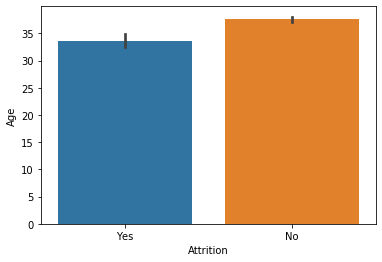

```python
sns.barplot(x="Attrition",y="Age",data=dataSet)
```

### Plot Total working years using matplotlib plot function

```python
  import matplotlib as plt
```

```python
dataSet_WrkYears = dataSet.loc[:,['TotalWorkingYears']]
```

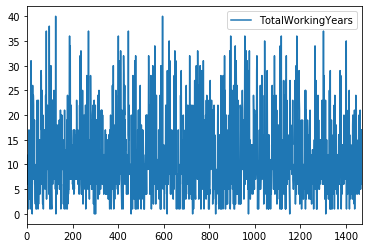

```python
dataSet_WrkYears.plot()
```